# DATA 608 Assignment 1

Salma Elshahawy

August 28, 2020

**Principles of Data Visualization and Introduction to ggplot2**

I have provided you with data about the 5,000 fastest growing companies in the US, as compiled by Inc. magazine. lets read this in:

```r
inc <- read.csv("https://raw.githubusercontent.com/charleyferrari/CUNY_DATA_608/master/module1/Data/inc5000_data.csv", header= TRUE)
```

And lets preview this data:

```r
head(inc)
```

|  | Rank | Name | Growth_Rate | Revenue | Industry | Employees | City | State |
| --- | --- | --- | --- | --- | --- | --- | --- | --- |
| 1 | 1 | Fuhu | 421.48 | 1.179e+08 | Consumer Products & Services | 104 | El Segundo | CA |
| 2 | 2 | FederalConference.com | 248.31 | 4.960e+07 | Government Services | 51 | Dumfries | VA |
| 3 | 3 | The HCI Group | 245.45 | 2.550e+07 | Health | 132 | Jacksonville | FL |
| 4 | 4 | Bridger | 233.08 | 1.900e+09 | Energy | 50 | Addison | TX |
| 5 | 5 | DataXu | 213.37 | 8.700e+07 | Advertising & Marketing | 220 | Boston | MA |
| 6 | 6 | MileStone Community Builders | 179.38 | 4.570e+07 | Real Estate | 63 | Austin | TX |

```r
NA
```

```r
summary(inc)
```

```
      Rank                          Name       Growth_Rate         Revenue                                  Industry      Employees
 Min.   :   1   (Add)ventures         :   1   Min.   :  0.340   Min.   :2.000e+06   IT Services                 : 733   Min.   :    1.0
 1st Qu.:1252   @Properties           :   1   1st Qu.:  0.770   1st Qu.:5.100e+06   Business Products & Services: 482   1st Qu.:   25.0
 Median :2502   1-Stop Translation USA:   1   Median :  1.420   Median :1.090e+07   Advertising & Marketing     : 471   Median :   53.0
 Mean   :2502   110 Consulting        :   1   Mean   :  4.612   Mean   :4.822e+07   Health                      : 355   Mean   :  232.7
 3rd Qu.:3751   11thStreetCoffee.com  :   1   3rd Qu.:  3.290   3rd Qu.:2.860e+07   Software                    : 342   3rd Qu.:  132.0
 Max.   :5000   123 Exteriors         :   1   Max.   :421.480   Max.   :1.010e+10   Financial Services          : 260   Max.   :66803.0
                (Other)               :4995                                         (Other)                     :2358   NA's   :12
            City          State
 New York     : 160   CA     : 701
 Chicago      :  90   TX     : 387
 Austin       :  88   NY     : 311
 Houston      :  76   VA     : 283
 San Francisco:  75   FL     : 282
 Atlanta      :  74   IL     : 273
 (Other)      :4438   (Other):2764
```

Think a bit on what these summaries mean. Use the space below to add some more relevant non-visual exploratory information you think helps you understand this data:

```r
library(dplyr)
# list types for each attribute
sapply(inc, class)
```

```
       Rank        Name Growth_Rate     Revenue    Industry   Employees        City       State
  "integer"    "factor"   "numeric"   "numeric"    "factor"   "integer"    "factor"    "factor"
```

```r
# Insert your code here, create more chunks as necessary
sd(inc$Growth_Rate)
```

```
[1] 14.12369
```

```r
sd(inc$Revenue)
```

```
[1] 240542281
```

```r
sd(inc$Employees, na.rm = TRUE)#A few companies have missing employee counts
```

```
[1] 1353.128
```

```r
#We can also do IQR in case the data is skewed
IQR(inc$Growth_Rate)
```

```
[1] 2.52
```

```r
IQR(inc$Revenue)
```

```
[1] 23500000
```

```r
IQR(inc$Employees, na.rm = TRUE)
```

```
[1] 107
```

```r
#Revenue has quite a large range. I used a base 10 logrithm to compress that scale.
#I used mutate from tidyr to make these new calculations part of the dataframe for later use.
inc <- inc %>% mutate(log_Rev = log10(Revenue))
inc$log_Rev %>% summary()
```

```
   Min. 1st Qu.  Median    Mean 3rd Qu.    Max.
  6.301   6.708   7.037   7.132   7.456  10.004
```

```r
# I also like doing ratios, in this case normalizing businesses of different sizes to see how much revenue or growth is generated per employee.
inc <- inc %>% mutate(rev_per_empl = Revenue/Employees)
inc$rev_per_empl %>% summary()
```

```
    Min.  1st Qu.   Median     Mean  3rd Qu.     Max.     NA's
    1801   125000   198658   393613   375000 40740000       12
```

```r
inc <- inc %>% mutate(grw_per_empl = Growth_Rate/Employees)
inc$grw_per_empl %>% summary()
```

```
     Min.   1st Qu.    Median      Mean   3rd Qu.      Max.      NA's
 0.000015  0.009022  0.027857  0.168649  0.093446 13.342500        12
```

```r
inc <- inc %>% mutate(log_rev_per_grw = log10(Revenue/Growth_Rate))
inc$log_rev_per_grw %>% summary()
```

```
   Min. 1st Qu.  Median    Mean 3rd Qu.    Max.
  5.015   6.376   6.873   6.876   7.366  10.392
```

```r
#  growth rate by industry
gr_industry<-inc %>%
  select (Industry,Growth_Rate) %>%
  group_by(Industry) %>%
  summarise(avg_gr= mean(Growth_Rate)) %>%
  arrange(desc(avg_gr))
head(gr_industry)
```

| Industry | avg_gr |
| --- | --- |
| Energy | 9.603303 |
| Consumer Products & Services | 8.776108 |
| Real Estate | 7.746667 |
| Government Services | 7.238168 |
| Advertising & Marketing | 6.225478 |
| Retail | 6.184729 |

```r
#  growth rate by city

gr_city<-inc %>%
  select (City,Growth_Rate) %>%
  group_by(City) %>%
  summarise(avg_gr= mean(Growth_Rate)) %>%
  arrange(desc(avg_gr))
head(gr_city)
```

| City | avg_gr |
| --- | --- |
| Dumfries | 248.31 |
| Chino | 110.68 |
| columbus | 100.10 |
| Cupertino | 92.45 |
| Bluffdale | 59.91 |
| El Segundo | 56.17 |

## Question 1

Create a graph that shows the distribution of companies in the dataset by State (ie how many are in each state). There are a lot of States, so consider which axis you should use. This visualization is ultimately going to be consumed on a ‘portrait’ oriented screen (ie taller than wide), which should further guide your layout choices.

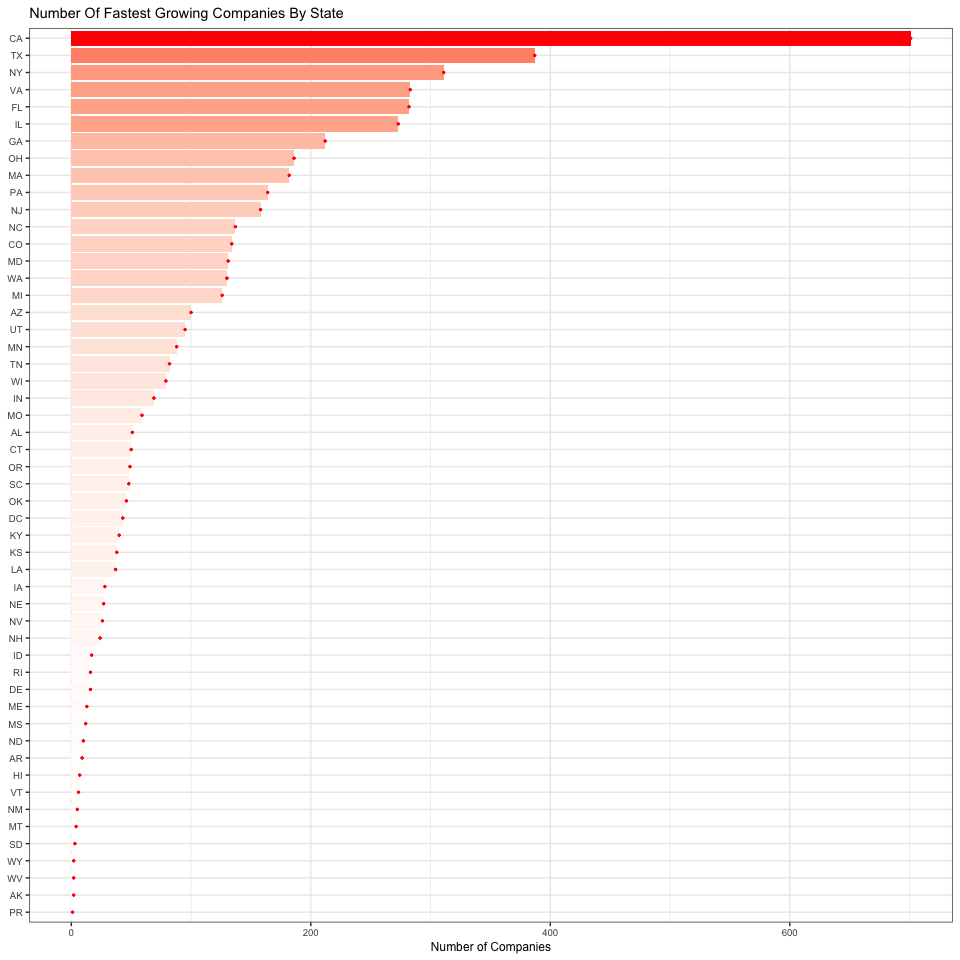

```r
q1_data<-inc %>%
  select (Name,State) %>%
  group_by(State) %>%
  dplyr::summarise(company_count = n_distinct(Name)) %>%
  arrange(desc(company_count))

q1<-ggplot(q1_data, aes(x=reorder(State,company_count), y=company_count)) +
  geom_bar(stat="identity")+
  geom_col(aes(fill = company_count)) +
  geom_point(size=0.5, colour = "red") +
  scale_fill_gradient2(low = "white", high = "red") +
  theme_bw()+
  coord_flip() +
  theme(text = element_text(size = 9, color = "black")) +
  ggtitle ("Number Of Fastest Growing Companies By State") + ylab("Number of Companies") +
  theme(axis.title.y=element_blank()) +
  theme(legend.position="none")

q1
```

## Quesiton 2

Lets dig in on the state with the 3rd most companies in the data set. Imagine you work for the state and are interested in how many people are employed by companies in different industries. Create a plot that shows the average and/or median employment by industry for companies in this state (only use cases with full data, use R’s `complete.cases()` function.) In addition to this, your graph should show how variable the ranges are, and you should deal with outliers.

```r
# Answer Question 2 here
ny_data <- inc  %>%
  filter(State == 'NY', complete.cases(.)) %>%
  arrange(Industry) %>% select(Industry, Employees)
ny_data <- ny_data %>% group_by(Industry) %>%
  filter(!(abs(Employees - median(Employees)) > 1.5*IQR(Employees)))# Using 1.5xIQR as the outlier limit
ny_data
```

| Industry | Employees |
| --- | --- |
| Advertising & Marketing | 79 |
| Advertising & Marketing | 27 |
| Advertising & Marketing | 89 |
| Advertising & Marketing | 75 |
| Advertising & Marketing | 42 |
| Advertising & Marketing | 15 |
| Advertising & Marketing | 46 |
| Advertising & Marketing | 19 |
| Advertising & Marketing | 45 |
| Advertising & Marketing | 12 |

[output cut: 252 more lines]

```r
#The 1.5xIQR rule reduced the number of negative error bars better than the 2xstd dev rule.
ind_means <- ny_data %>%
  group_by(Industry) %>%
  summarise(mean_emp = mean(Employees), emp_sd = sd(Employees))
ind_means$emp_sd[is.na(ind_means$emp_sd)] <- 0
ind_means
```

| Industry | mean_emp | emp_sd |
| --- | --- | --- |
| Advertising & Marketing | 38.24000 | 24.243291 |
| Business Products & Services | 101.90476 | 121.897869 |
| Computer Hardware | 44.00000 | 0.000000 |
| Construction | 29.40000 | 22.378561 |
| Consumer Products & Services | 36.46667 | 28.083718 |
| Education | 49.07692 | 28.170497 |
| Energy | 115.66667 | 23.797759 |
| Engineering | 53.50000 | 39.786933 |
| Environmental Services | 155.00000 | 134.350288 |
| Financial Services | 88.00000 | 68.939104 |

[output cut: 15 more lines]

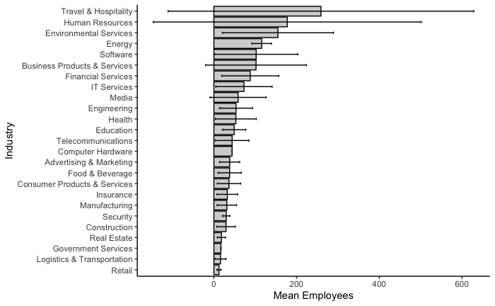

```r
ggplot(ind_means, aes(x=reorder(Industry, mean_emp),y=mean_emp)) +
  geom_bar(stat='identity', color = 'black', fill='lightgray') +
  geom_errorbar(aes(ymin = mean_emp - emp_sd, ymax = mean_emp + emp_sd), width=0.2) +
  theme(legend.position="none") +
  ylab('Mean Employees')+ xlab('Industry')+
  coord_flip() +
  theme_classic()
```

## Question 3

Now imagine you work for an investor and want to see which industries generate the most revenue per employee. Create a chart that makes this information clear. Once again, the distribution per industry should be shown.

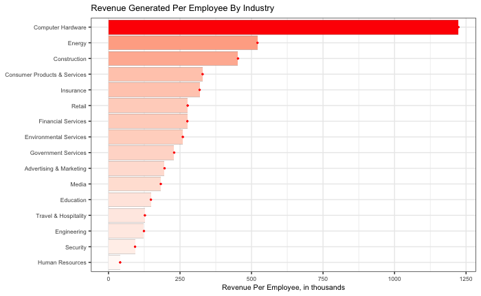

```r
# Answer Question 3 here
q3_data<-inc %>%
  select (Revenue, Industry, Employees) %>%
  group_by(Industry) %>%
  summarise(total_revenue = sum(Revenue), total_employee = sum(Employees)) %>%
  mutate(revenue_employee = total_revenue / total_employee/1000) %>%
  arrange (revenue_employee)

q3_data <- q3_data[complete.cases(q3_data$Industry), ]
q3_data <- q3_data[complete.cases(q3_data$total_employee), ]

q3<-ggplot(q3_data, aes(x=reorder(Industry, revenue_employee), y=revenue_employee)) +
  geom_bar(stat="identity")+
  theme_bw()+
  geom_col(aes(fill = revenue_employee)) +
  geom_point(size=0.5, colour = "red") +
  scale_fill_gradient2(low = "white", high = "red") +
  coord_flip() +
  ggtitle ("Revenue Generated Per Employee By Industry") + ylab("Revenue Per Employee, in thousands") +
  theme(legend.position="none") +
  theme(axis.title.y=element_blank())+
  theme(text = element_text(size = 8, color = "black"))

q3
```